# Notes 01 - What is Statistics? What is Data?

STS272 (Fall 2020) - Dr. VanKrevelen

Updated: 7/14/2020

# 1 Reading for Notes 01

Read the [“Introduction for Students”](https://moderndive.com/preface.html#introduction-for-students) part of the Preface in the Modern Dive textbook

# 2 Learning Goals for Notes 01

- Gain a brief understanding of how statistics (as a field) is used
- Understand how to talk about data through key terminology like observation, variable, etc.
- Understand how to distinguish between different types of variables
- Begin to consider how bias can have an impact on statistics

# 3 What is Statistics?

What do you think of when you think of statistics?

Where/how is statistics used?

# 4 The Basic Steps of a Statistical Analysis

There’s no one way to do statistics or data science, but below are four general steps that one might follow when doing a statistical analysis.

**1. Formulate a Question. Come up with a plan to answer that question.**

The process of statistics usually starts with a question. For example, “Does this new drug reduce allergy symptoms more than its competitor?” or “Are men more likely to be promoted than equally qualified women at NASA?”. You should carefully consider what question you really hope to answer because that will affect each of the steps that follow. Consider how you plan to use the answers you get as well. What group of people / objects do you hope to ultimately apply your answers to?

**2. Collect Data to help you answer the question**

To answer these questions, we need to gather information. Sometimes this means setting up an *experiment* (e.g. giving some people a new allergy drug and some people the current drug and tracking their symptoms). Other times this means finding data that already exists in what’s called an *observational study* (e.g. gathering a list of past NASA promotions along with information like years of experience, publications, etc.). This data will only be useful to us if it is *representative* of our group we’re interested in studying (more on this later).

**3. Summarize the data both visually and numerically (Descriptive statistics)**

The first thing we should do with our data is to summarize it. This may seem like we’re answering our initial question, but usually that’s not the case. Often our data is only a small piece of our question (e.g. our experiment may have 100 participants but we want to know if this drug will work for *all* allergy sufferers, not just those 100 people). By summarizing our data though, we get to see initial trends, and it helps us better understand the results we reach later. What we learn in this step can be crucial in helping us explain our ultimate results to someone else.

**4. Make Inference / Draw Conclusions beyond your data (Inferential statistics)**

If possible, we usually want to draw conclusions beyond just the data that we have. That may mean extending it to people who weren’t part of our data or using it to predict things in the future. The power of statistics is that often we can use a small group to make conclusions about a much larger group (e.g. how election polling can help us understand how *all* probably voters feel even though we can’t talk to millions of people.)

**Brainstorm**: This year’s common read, Biased by Jennifer Eberhardt, focused on human biases. While people like to think of statistics as objective and fact-based, there are all sorts of ways bias can creep into a statistical study. What are some ways that bias might get introduced into a statistical study at different points in the steps described above?

# 5 Some Important Terms

To be able to talk to each other about various examples, we need some common terminology we can use. It’s ok if you don’t have these down right away, but we’ll want to start identifying these things when we do different examples.

**Population** - The complete group of people/things that we want to learn about.

- When we define our question in step 1 above, we should have a clear idea of the population to which we want our question to apply.
- Usually we don’t have information from the entire population, so we use a sample.

**Parameter** - A specific number that describes some aspect of our population.

- Oftentimes our question above may be able to be directly phrased in terms of a parameter. For example “What is the average high school GPA of Elon students?” or “What percentage of Elon students are vegetarian?”

**Sample** - A subset of the population from which we actually have information.

- This is the information we gather in step 2 above. Since we can’t usually get information from the whole population.
- As mentioned before, samples are really only helpful if they are *representative* of the population.
- A sample may also be referred to as the data, or a data set.

**Statistic** - A specific number that describes some aspect of our sample.

- This is part of step 3 above. Unlike parameters, we can actually calculate statistics (e.g. “the average high school GPA of 25 Elon students was 3.4” or “15% of our sample of 50 Elon students is a vegetarian”)
- Eventually we will use these statistics to make *inference* about our population. For example, I probably don’t think exactly 15% of all Elon students are vegetarian, but I might think tthe corresponding parameter is close to that based on what I’ve seen.
- We will revisit this more after exam 1.

**Observation** – A person/object on which we are recording information

- Typically rows in our data set represent different observations

**Variable** – Any characteristic that we can measure/record for an object or subject.

- In other words, it varies from observation to observation.
- There are multiple different kinds of variables (see below)
- Typically columns in our dataset represent different variables

**Quantitative variable** - A variable that has a numeric meaning.

- As a general rule, if it would make sense to calculate the average, then it is a quantitative variable.
- Examples include a person’s income, a city’s square footage, or a movie’s budget

**Categorical (or qualitative) variable** - A variable that does *not* have a numeric meaning.

- These variables are usually groups or labels for a person/object.
- Examples include a person’s blood type, a neighborhood’s zip code, or a movie’s genre

Note: The groups or categories within a variable are called levels.

**Practice Questions**

Below is a picture of part of a dataset in R called starwars. You can see that we have information on 10 different characters from the Star Wars movies. Use the picture to answer the practice questions on Moodle.

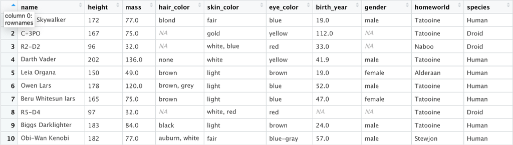

Figure 1: Picture of part of a dataset in R called starwars

# 6 Some ideas to consider going forward

- Doing statistics well can be difficult. It can also be really rewarding and can help shed light on important issues in a wide range of fields.
- As we proceed through the course, you should be reflecting on what we’re doing and why we’re doing it. If something doesn’t make sense, just ask! Each of you has a unique perspective that can help us all learn to better interrogate our assumptions, our methods, and our conclusions. Statistics is all about explaining what we know and what we don’t know. There often isn’t one “right” answer in the real world.
- We will be learning some computer programming. The best way to get better at this is to practice, practice, practice. Re-do examples from class. Try things we did on one example on another example. Find data that interests you and practice with that.

# 7 Revisiting the Learning Goals for Notes 01

- Gain a brief understanding of how statistics (as a field) is used
  - Many students (and schools) group statistics and math together, but how is a statistics class maybe different from a typical math class?
  - What is the difference between doing statistics vs. citing a statistic?
- Understand how to talk about data through key terminology like observation, variable, etc.
  - Consider a dataset of all the students in this class that measures things like your height, hometown, anticipated major, and number of previous statistics classes taken. What would an observation in this dataset be? What about a variable?
- Understand how to distinguish between different types of variables
  - Identify at least one quantitative variable and at least one categorical variable from the example above.
- Begin to consider how bias can have an impact on statistics
  - Pick one of the following questions and think about how bias may impact a study at each of the four steps described above. (Note: This question may be a bit difficult now. I encourage you to discuss it with a classmate or with me. If you’re having a hard time, consider revisiting it after we’ve covered a couple more sections of the notes.)
    - How much do students learn with in person classes compared to online classes?
    - What percentage of felony convictions are wrongful?
    - Does a new drug reduce cholesterol more than the current drug on the market?